# Optimal Treatment Analysis

## Outcome Variable

**Outcome Variable:** ever_wasted

## Predictor Variables

**Intervention Variable:** hdlvry

**Adjustment Set:**

- arm
- sex
- W_mage
- meducyrs
- feducyrs
- single
- W_nrooms
- W_parity
- impsan
- delta_W_mage
- delta_meducyrs
- delta_feducyrs
- delta_single
- delta_W_nrooms
- delta_W_parity
- delta_impsan

## Stratifying Variables

The analysis was stratified on these variable(s):

- agecat
- studyid
- country

## Data Summary

| agecat | studyid | country | hdlvry | ever_wasted | n_cell | n |
| --- | --- | --- | --- | --- | --- | --- |
| 0-24 months (no birth wast) | ki1000108-CMC-V-BCS-2002 | INDIA | 0 | 0 | 196 | 365 |
| 0-24 months (no birth wast) | ki1000108-CMC-V-BCS-2002 | INDIA | 0 | 1 | 161 | 365 |
| 0-24 months (no birth wast) | ki1000108-CMC-V-BCS-2002 | INDIA | 1 | 0 | 5 | 365 |
| 0-24 months (no birth wast) | ki1000108-CMC-V-BCS-2002 | INDIA | 1 | 1 | 3 | 365 |
| 0-24 months (no birth wast) | ki1000108-IRC | INDIA | 0 | 0 | 190 | 409 |
| 0-24 months (no birth wast) | ki1000108-IRC | INDIA | 0 | 1 | 211 | 409 |
| 0-24 months (no birth wast) | ki1000108-IRC | INDIA | 1 | 0 | 6 | 409 |
| 0-24 months (no birth wast) | ki1000108-IRC | INDIA | 1 | 1 | 2 | 409 |
| 0-24 months (no birth wast) | ki1000109-EE | PAKISTAN | 0 | 0 | 143 | 375 |
| 0-24 months (no birth wast) | ki1000109-EE | PAKISTAN | 0 | 1 | 109 | 375 |
| 0-24 months (no birth wast) | ki1000109-EE | PAKISTAN | 1 | 0 | 68 | 375 |
| 0-24 months (no birth wast) | ki1000109-EE | PAKISTAN | 1 | 1 | 55 | 375 |
| 0-24 months (no birth wast) | ki1000304b-SAS-CompFeed | INDIA | 0 | 0 | 57 | 395 |
| 0-24 months (no birth wast) | ki1000304b-SAS-CompFeed | INDIA | 0 | 1 | 20 | 395 |
| 0-24 months (no birth wast) | ki1000304b-SAS-CompFeed | INDIA | 1 | 0 | 198 | 395 |
| 0-24 months (no birth wast) | ki1000304b-SAS-CompFeed | INDIA | 1 | 1 | 120 | 395 |
| 0-24 months (no birth wast) | ki1000304b-SAS-FoodSuppl | INDIA | 0 | 0 | 17 | 100 |
| 0-24 months (no birth wast) | ki1000304b-SAS-FoodSuppl | INDIA | 0 | 1 | 6 | 100 |
| 0-24 months (no birth wast) | ki1000304b-SAS-FoodSuppl | INDIA | 1 | 0 | 43 | 100 |
| 0-24 months (no birth wast) | ki1000304b-SAS-FoodSuppl | INDIA | 1 | 1 | 34 | 100 |
| 0-24 months (no birth wast) | ki1017093b-PROVIDE | BANGLADESH | 0 | 0 | 427 | 687 |
| 0-24 months (no birth wast) | ki1017093b-PROVIDE | BANGLADESH | 0 | 1 | 86 | 687 |
| 0-24 months (no birth wast) | ki1017093b-PROVIDE | BANGLADESH | 1 | 0 | 138 | 687 |
| 0-24 months (no birth wast) | ki1017093b-PROVIDE | BANGLADESH | 1 | 1 | 36 | 687 |
| 0-24 months (no birth wast) | ki1017093c-NIH-Crypto | BANGLADESH | 0 | 0 | 513 | 754 |
| 0-24 months (no birth wast) | ki1017093c-NIH-Crypto | BANGLADESH | 0 | 1 | 74 | 754 |
| 0-24 months (no birth wast) | ki1017093c-NIH-Crypto | BANGLADESH | 1 | 0 | 133 | 754 |
| 0-24 months (no birth wast) | ki1017093c-NIH-Crypto | BANGLADESH | 1 | 1 | 34 | 754 |
| 0-24 months (no birth wast) | ki1066203-TanzaniaChild2 | TANZANIA, UNITED REPUBLIC OF | 0 | 0 | 1776 | 2262 |
| 0-24 months (no birth wast) | ki1066203-TanzaniaChild2 | TANZANIA, UNITED REPUBLIC OF | 0 | 1 | 446 | 2262 |

[output cut: 114 more lines]

The following strata were considered:

- agecat: 0-24 months (no birth wast), studyid: ki1000108-CMC-V-BCS-2002, country: INDIA
- agecat: 0-24 months (no birth wast), studyid: ki1000108-IRC, country: INDIA
- agecat: 0-24 months (no birth wast), studyid: ki1000109-EE, country: PAKISTAN
- agecat: 0-24 months (no birth wast), studyid: ki1000304b-SAS-CompFeed, country: INDIA
- agecat: 0-24 months (no birth wast), studyid: ki1000304b-SAS-FoodSuppl, country: INDIA
- agecat: 0-24 months (no birth wast), studyid: ki1017093b-PROVIDE, country: BANGLADESH
- agecat: 0-24 months (no birth wast), studyid: ki1017093c-NIH-Crypto, country: BANGLADESH
- agecat: 0-24 months (no birth wast), studyid: ki1066203-TanzaniaChild2, country: TANZANIA, UNITED REPUBLIC OF
- agecat: 0-24 months (no birth wast), studyid: ki1113344-GMS-Nepal, country: NEPAL
- agecat: 0-24 months (no birth wast), studyid: ki1135781-COHORTS, country: INDIA
- agecat: 0-24 months (no birth wast), studyid: kiGH5241-JiVitA-3, country: BANGLADESH
- agecat: 0-24 months (no birth wast), studyid: kiGH5241-JiVitA-4, country: BANGLADESH
- agecat: 0-6 months (no birth wast), studyid: ki1000108-CMC-V-BCS-2002, country: INDIA
- agecat: 0-6 months (no birth wast), studyid: ki1000108-IRC, country: INDIA
- agecat: 0-6 months (no birth wast), studyid: ki1000109-EE, country: PAKISTAN
- agecat: 0-6 months (no birth wast), studyid: ki1000304b-SAS-CompFeed, country: INDIA
- agecat: 0-6 months (no birth wast), studyid: ki1000304b-SAS-FoodSuppl, country: INDIA
- agecat: 0-6 months (no birth wast), studyid: ki1017093b-PROVIDE, country: BANGLADESH
- agecat: 0-6 months (no birth wast), studyid: ki1017093c-NIH-Crypto, country: BANGLADESH
- agecat: 0-6 months (no birth wast), studyid: ki1066203-TanzaniaChild2, country: TANZANIA, UNITED REPUBLIC OF
- agecat: 0-6 months (no birth wast), studyid: ki1113344-GMS-Nepal, country: NEPAL
- agecat: 0-6 months (no birth wast), studyid: ki1135781-COHORTS, country: INDIA
- agecat: 0-6 months (no birth wast), studyid: kiGH5241-JiVitA-3, country: BANGLADESH
- agecat: 0-6 months (no birth wast), studyid: kiGH5241-JiVitA-4, country: BANGLADESH
- agecat: 6-24 months, studyid: ki1000108-CMC-V-BCS-2002, country: INDIA
- agecat: 6-24 months, studyid: ki1000108-IRC, country: INDIA
- agecat: 6-24 months, studyid: ki1000109-EE, country: PAKISTAN
- agecat: 6-24 months, studyid: ki1000304b-SAS-CompFeed, country: INDIA
- agecat: 6-24 months, studyid: ki1000304b-SAS-FoodSuppl, country: INDIA
- agecat: 6-24 months, studyid: ki1017093b-PROVIDE, country: BANGLADESH
- agecat: 6-24 months, studyid: ki1017093c-NIH-Crypto, country: BANGLADESH
- agecat: 6-24 months, studyid: ki1066203-TanzaniaChild2, country: TANZANIA, UNITED REPUBLIC OF
- agecat: 6-24 months, studyid: ki1113344-GMS-Nepal, country: NEPAL
- agecat: 6-24 months, studyid: ki1135781-COHORTS, country: INDIA
- agecat: 6-24 months, studyid: kiGH5241-JiVitA-3, country: BANGLADESH
- agecat: 6-24 months, studyid: kiGH5241-JiVitA-4, country: BANGLADESH

### Dropped Strata

Some strata were dropped due to rare outcomes:

- agecat: 0-24 months (no birth wast), studyid: ki1000108-CMC-V-BCS-2002, country: INDIA
- agecat: 0-24 months (no birth wast), studyid: ki1000108-IRC, country: INDIA
- agecat: 0-24 months (no birth wast), studyid: kiGH5241-JiVitA-3, country: BANGLADESH
- agecat: 0-6 months (no birth wast), studyid: ki1000108-CMC-V-BCS-2002, country: INDIA
- agecat: 0-6 months (no birth wast), studyid: ki1000108-IRC, country: INDIA
- agecat: 0-6 months (no birth wast), studyid: ki1000304b-SAS-FoodSuppl, country: INDIA
- agecat: 0-6 months (no birth wast), studyid: ki1066203-TanzaniaChild2, country: TANZANIA, UNITED REPUBLIC OF
- agecat: 0-6 months (no birth wast), studyid: kiGH5241-JiVitA-3, country: BANGLADESH
- agecat: 6-24 months, studyid: ki1000108-CMC-V-BCS-2002, country: INDIA
- agecat: 6-24 months, studyid: ki1000108-IRC, country: INDIA
- agecat: 6-24 months, studyid: ki1066203-TanzaniaChild2, country: TANZANIA, UNITED REPUBLIC OF
- agecat: 6-24 months, studyid: kiGH5241-JiVitA-3, country: BANGLADESH

## Methods Detail

We’re interested in the causal parameters $E[Y_a]$ for all values of $a \in \mathcal{A}$. These parameters represent the mean outcome if, possibly contrary to fact, we intervened to set all units to have $A=a$. Under the randomization and positivity assumptions, these are identified by the statistical parameters $\psi_a=E_W[E_{Y|A,W}(Y|A=a,W)]$. In addition, we’re interested in the mean of $Y$, $E[Y]$ under no intervention (the observed mean). We will estimate these parameters by using SuperLearner to fit the relevant likelihood factors – $E_{Y|A,W}(Y|A=a,W)$ and $p(A=a|W)$, and then updating our likelihood fit using a joint TMLE.

For unadjusted analyses ($W=\{\}$), initial likelihoods were estimated using Lrnr_glm to estimate the simple $E(Y|A)$ and Lrnr_mean to estimate $p(A)$. For adjusted analyses, a small library containing Lrnr_glmnet, Lrnr_xgboost, and Lrnr_mean was used.

Having estimated these parameters, we will then use the delta method to estimate relative risks and attributable risks relative to a prespecified baseline level of $A$.

# Results Detail

## Results Plots

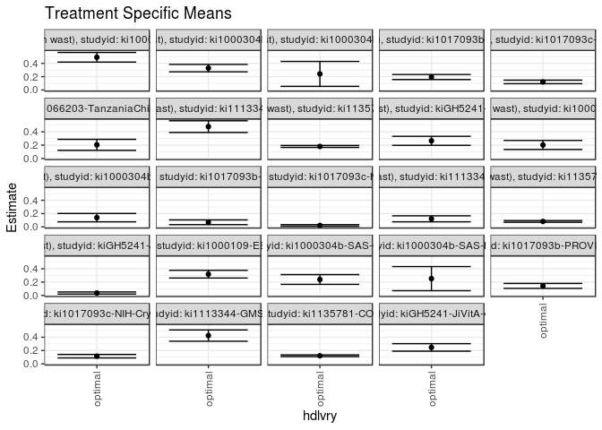

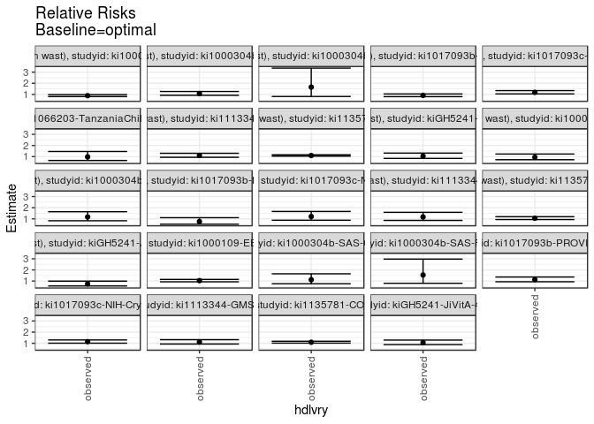

## Results Table

### Parameter: TSM

| agecat | studyid | country | intervention_level | baseline_level | estimate | ci_lower | ci_upper |
| --- | --- | --- | --- | --- | --- | --- | --- |
| 0-24 months (no birth wast) | ki1000109-EE | PAKISTAN | optimal | NA | 0.4916465 | 0.4192643 | 0.5640286 |
| 0-24 months (no birth wast) | ki1000304b-SAS-CompFeed | INDIA | optimal | NA | 0.3285011 | 0.2729257 | 0.3840766 |
| 0-24 months (no birth wast) | ki1000304b-SAS-FoodSuppl | INDIA | optimal | NA | 0.2415849 | 0.0540866 | 0.4290832 |
| 0-24 months (no birth wast) | ki1017093b-PROVIDE | BANGLADESH | optimal | NA | 0.1945478 | 0.1566094 | 0.2324861 |
| 0-24 months (no birth wast) | ki1017093c-NIH-Crypto | BANGLADESH | optimal | NA | 0.1208362 | 0.0941323 | 0.1475401 |
| 0-24 months (no birth wast) | ki1066203-TanzaniaChild2 | TANZANIA, UNITED REPUBLIC OF | optimal | NA | 0.2046669 | 0.1221285 | 0.2872053 |
| 0-24 months (no birth wast) | ki1113344-GMS-Nepal | NEPAL | optimal | NA | 0.4783488 | 0.3903589 | 0.5663387 |
| 0-24 months (no birth wast) | ki1135781-COHORTS | INDIA | optimal | NA | 0.1801522 | 0.1654913 | 0.1948131 |
| 0-24 months (no birth wast) | kiGH5241-JiVitA-4 | BANGLADESH | optimal | NA | 0.2647344 | 0.1972557 | 0.3322132 |
| 0-6 months (no birth wast) | ki1000109-EE | PAKISTAN | optimal | NA | 0.2026277 | 0.1345838 | 0.2706717 |
| 0-6 months (no birth wast) | ki1000304b-SAS-CompFeed | INDIA | optimal | NA | 0.1390742 | 0.0763318 | 0.2018167 |
| 0-6 months (no birth wast) | ki1017093b-PROVIDE | BANGLADESH | optimal | NA | 0.0696198 | 0.0337939 | 0.1054457 |
| 0-6 months (no birth wast) | ki1017093c-NIH-Crypto | BANGLADESH | optimal | NA | 0.0221071 | 0.0101614 | 0.0340528 |
| 0-6 months (no birth wast) | ki1113344-GMS-Nepal | NEPAL | optimal | NA | 0.1214999 | 0.0761724 | 0.1668273 |
| 0-6 months (no birth wast) | ki1135781-COHORTS | INDIA | optimal | NA | 0.0822485 | 0.0694519 | 0.0950451 |
| 0-6 months (no birth wast) | kiGH5241-JiVitA-4 | BANGLADESH | optimal | NA | 0.0357632 | 0.0202286 | 0.0512977 |
| 6-24 months | ki1000109-EE | PAKISTAN | optimal | NA | 0.3184068 | 0.2605438 | 0.3762697 |
| 6-24 months | ki1000304b-SAS-CompFeed | INDIA | optimal | NA | 0.2388734 | 0.1656435 | 0.3121033 |
| 6-24 months | ki1000304b-SAS-FoodSuppl | INDIA | optimal | NA | 0.2517085 | 0.0703149 | 0.4331021 |
| 6-24 months | ki1017093b-PROVIDE | BANGLADESH | optimal | NA | 0.1425215 | 0.1056181 | 0.1794249 |
| 6-24 months | ki1017093c-NIH-Crypto | BANGLADESH | optimal | NA | 0.1149537 | 0.0886363 | 0.1412710 |
| 6-24 months | ki1113344-GMS-Nepal | NEPAL | optimal | NA | 0.4248082 | 0.3400301 | 0.5095862 |
| 6-24 months | ki1135781-COHORTS | INDIA | optimal | NA | 0.1211366 | 0.1081245 | 0.1341488 |
| 6-24 months | kiGH5241-JiVitA-4 | BANGLADESH | optimal | NA | 0.2468800 | 0.1905140 | 0.3032460 |

### Parameter: E(Y)

| agecat | studyid | country | intervention_level | baseline_level | estimate | ci_lower | ci_upper |
| --- | --- | --- | --- | --- | --- | --- | --- |
| 0-24 months (no birth wast) | ki1000109-EE | PAKISTAN | observed | NA | 0.4373333 | 0.3870592 | 0.4876074 |
| 0-24 months (no birth wast) | ki1000304b-SAS-CompFeed | INDIA | observed | NA | 0.3544304 | 0.2614867 | 0.4473741 |
| 0-24 months (no birth wast) | ki1000304b-SAS-FoodSuppl | INDIA | observed | NA | 0.4000000 | 0.3034980 | 0.4965020 |
| 0-24 months (no birth wast) | ki1017093b-PROVIDE | BANGLADESH | observed | NA | 0.1775837 | 0.1489858 | 0.2061816 |
| 0-24 months (no birth wast) | ki1017093c-NIH-Crypto | BANGLADESH | observed | NA | 0.1432361 | 0.1182149 | 0.1682572 |
| 0-24 months (no birth wast) | ki1066203-TanzaniaChild2 | TANZANIA, UNITED REPUBLIC OF | observed | NA | 0.2002653 | 0.1837694 | 0.2167611 |
| 0-24 months (no birth wast) | ki1113344-GMS-Nepal | NEPAL | observed | NA | 0.5290909 | 0.4873371 | 0.5708447 |
| 0-24 months (no birth wast) | ki1135781-COHORTS | INDIA | observed | NA | 0.1978741 | 0.1867089 | 0.2090392 |
| 0-24 months (no birth wast) | kiGH5241-JiVitA-4 | BANGLADESH | observed | NA | 0.2787724 | 0.2485492 | 0.3089955 |
| 0-6 months (no birth wast) | ki1000109-EE | PAKISTAN | observed | NA | 0.1913747 | 0.1512914 | 0.2314579 |
| 0-6 months (no birth wast) | ki1000304b-SAS-CompFeed | INDIA | observed | NA | 0.1623711 | 0.0945196 | 0.2302227 |
| 0-6 months (no birth wast) | ki1017093b-PROVIDE | BANGLADESH | observed | NA | 0.0527086 | 0.0359384 | 0.0694789 |
| 0-6 months (no birth wast) | ki1017093c-NIH-Crypto | BANGLADESH | observed | NA | 0.0267023 | 0.0151493 | 0.0382553 |
| 0-6 months (no birth wast) | ki1113344-GMS-Nepal | NEPAL | observed | NA | 0.1417769 | 0.1120237 | 0.1715302 |
| 0-6 months (no birth wast) | ki1135781-COHORTS | INDIA | observed | NA | 0.0867694 | 0.0784641 | 0.0950747 |
| 0-6 months (no birth wast) | kiGH5241-JiVitA-4 | BANGLADESH | observed | NA | 0.0267380 | 0.0164185 | 0.0370574 |
| 6-24 months | ki1000109-EE | PAKISTAN | observed | NA | 0.3297587 | 0.2819849 | 0.3775326 |
| 6-24 months | ki1000304b-SAS-CompFeed | INDIA | observed | NA | 0.2673797 | 0.2109177 | 0.3238416 |
| 6-24 months | ki1000304b-SAS-FoodSuppl | INDIA | observed | NA | 0.3883495 | 0.2937670 | 0.4829321 |
| 6-24 months | ki1017093b-PROVIDE | BANGLADESH | observed | NA | 0.1609756 | 0.1319065 | 0.1900447 |
| 6-24 months | ki1017093c-NIH-Crypto | BANGLADESH | observed | NA | 0.1315068 | 0.1069744 | 0.1560393 |
| 6-24 months | ki1113344-GMS-Nepal | NEPAL | observed | NA | 0.4717668 | 0.4299709 | 0.5135628 |
| 6-24 months | ki1135781-COHORTS | INDIA | observed | NA | 0.1326445 | 0.1229894 | 0.1422995 |
| 6-24 months | kiGH5241-JiVitA-4 | BANGLADESH | observed | NA | 0.2627119 | 0.2334227 | 0.2920010 |

### Parameter: RR

| agecat | studyid | country | intervention_level | baseline_level | estimate | ci_lower | ci_upper |
| --- | --- | --- | --- | --- | --- | --- | --- |
| 0-24 months (no birth wast) | ki1000109-EE | PAKISTAN | observed | optimal | 0.8895281 | 0.8054295 | 0.9824078 |
| 0-24 months (no birth wast) | ki1000304b-SAS-CompFeed | INDIA | observed | optimal | 1.0789320 | 0.9226106 | 1.2617393 |
| 0-24 months (no birth wast) | ki1000304b-SAS-FoodSuppl | INDIA | observed | optimal | 1.6557328 | 0.8155977 | 3.3612786 |
| 0-24 months (no birth wast) | ki1017093b-PROVIDE | BANGLADESH | observed | optimal | 0.9128026 | 0.8014175 | 1.0396686 |
| 0-24 months (no birth wast) | ki1017093c-NIH-Crypto | BANGLADESH | observed | optimal | 1.1853739 | 1.0453382 | 1.3441690 |
| 0-24 months (no birth wast) | ki1066203-TanzaniaChild2 | TANZANIA, UNITED REPUBLIC OF | observed | optimal | 0.9784937 | 0.6559772 | 1.4595779 |
| 0-24 months (no birth wast) | ki1113344-GMS-Nepal | NEPAL | observed | optimal | 1.1060776 | 0.9412410 | 1.2997816 |
| 0-24 months (no birth wast) | ki1135781-COHORTS | INDIA | observed | optimal | 1.0983718 | 1.0376502 | 1.1626468 |
| 0-24 months (no birth wast) | kiGH5241-JiVitA-4 | BANGLADESH | observed | optimal | 1.0530266 | 0.8417590 | 1.3173188 |
| 0-6 months (no birth wast) | ki1000109-EE | PAKISTAN | observed | optimal | 0.9444643 | 0.7235981 | 1.2327462 |
| 0-6 months (no birth wast) | ki1000304b-SAS-CompFeed | INDIA | observed | optimal | 1.1675143 | 0.8306998 | 1.6408934 |
| 0-6 months (no birth wast) | ki1017093b-PROVIDE | BANGLADESH | observed | optimal | 0.7570923 | 0.5191495 | 1.1040919 |
| 0-6 months (no birth wast) | ki1017093c-NIH-Crypto | BANGLADESH | observed | optimal | 1.2078597 | 0.8783530 | 1.6609781 |
| 0-6 months (no birth wast) | ki1113344-GMS-Nepal | NEPAL | observed | optimal | 1.1668895 | 0.8593297 | 1.5845268 |
| 0-6 months (no birth wast) | ki1135781-COHORTS | INDIA | observed | optimal | 1.0549657 | 0.9346414 | 1.1907803 |
| 0-6 months (no birth wast) | kiGH5241-JiVitA-4 | BANGLADESH | observed | optimal | 0.7476400 | 0.5628874 | 0.9930326 |
| 6-24 months | ki1000109-EE | PAKISTAN | observed | optimal | 1.0356523 | 0.9323392 | 1.1504135 |
| 6-24 months | ki1000304b-SAS-CompFeed | INDIA | observed | optimal | 1.1193364 | 0.7593832 | 1.6499102 |
| 6-24 months | ki1000304b-SAS-FoodSuppl | INDIA | observed | optimal | 1.5428540 | 0.8017190 | 2.9691182 |
| 6-24 months | ki1017093b-PROVIDE | BANGLADESH | observed | optimal | 1.1294832 | 0.9360961 | 1.3628221 |
| 6-24 months | ki1017093c-NIH-Crypto | BANGLADESH | observed | optimal | 1.1439986 | 1.0068777 | 1.2997932 |
| 6-24 months | ki1113344-GMS-Nepal | NEPAL | observed | optimal | 1.1105408 | 0.9326935 | 1.3223004 |
| 6-24 months | ki1135781-COHORTS | INDIA | observed | optimal | 1.0949988 | 1.0134523 | 1.1831067 |
| 6-24 months | kiGH5241-JiVitA-4 | BANGLADESH | observed | optimal | 1.0641279 | 0.8774647 | 1.2904999 |

### Parameter: PAR

| agecat | studyid | country | intervention_level | baseline_level | estimate | ci_lower | ci_upper |
| --- | --- | --- | --- | --- | --- | --- | --- |
| 0-24 months (no birth wast) | ki1000109-EE | PAKISTAN | optimal | NA | -0.0543131 | -0.1031566 | -0.0054697 |
| 0-24 months (no birth wast) | ki1000304b-SAS-CompFeed | INDIA | optimal | NA | 0.0259292 | -0.0309966 | 0.0828550 |
| 0-24 months (no birth wast) | ki1000304b-SAS-FoodSuppl | INDIA | optimal | NA | 0.1584151 | -0.0121288 | 0.3289590 |
| 0-24 months (no birth wast) | ki1017093b-PROVIDE | BANGLADESH | optimal | NA | -0.0169641 | -0.0421133 | 0.0081852 |
| 0-24 months (no birth wast) | ki1017093c-NIH-Crypto | BANGLADESH | optimal | NA | 0.0223999 | 0.0069315 | 0.0378682 |
| 0-24 months (no birth wast) | ki1066203-TanzaniaChild2 | TANZANIA, UNITED REPUBLIC OF | optimal | NA | -0.0044016 | -0.0862240 | 0.0774207 |
| 0-24 months (no birth wast) | ki1113344-GMS-Nepal | NEPAL | optimal | NA | 0.0507421 | -0.0263095 | 0.1277938 |
| 0-24 months (no birth wast) | ki1135781-COHORTS | INDIA | optimal | NA | 0.0177219 | 0.0074597 | 0.0279841 |
| 0-24 months (no birth wast) | kiGH5241-JiVitA-4 | BANGLADESH | optimal | NA | 0.0140380 | -0.0451672 | 0.0732432 |
| 0-6 months (no birth wast) | ki1000109-EE | PAKISTAN | optimal | NA | -0.0112531 | -0.0652373 | 0.0427312 |
| 0-6 months (no birth wast) | ki1000304b-SAS-CompFeed | INDIA | optimal | NA | 0.0232969 | -0.0278611 | 0.0744549 |
| 0-6 months (no birth wast) | ki1017093b-PROVIDE | BANGLADESH | optimal | NA | -0.0169112 | -0.0441857 | 0.0103633 |
| 0-6 months (no birth wast) | ki1017093c-NIH-Crypto | BANGLADESH | optimal | NA | 0.0045952 | -0.0026994 | 0.0118898 |
| 0-6 months (no birth wast) | ki1113344-GMS-Nepal | NEPAL | optimal | NA | 0.0202770 | -0.0170873 | 0.0576414 |
| 0-6 months (no birth wast) | ki1135781-COHORTS | INDIA | optimal | NA | 0.0045208 | -0.0054418 | 0.0144835 |
| 0-6 months (no birth wast) | kiGH5241-JiVitA-4 | BANGLADESH | optimal | NA | -0.0090252 | -0.0191245 | 0.0010741 |
| 6-24 months | ki1000109-EE | PAKISTAN | optimal | NA | 0.0113519 | -0.0220963 | 0.0448001 |
| 6-24 months | ki1000304b-SAS-CompFeed | INDIA | optimal | NA | 0.0285063 | -0.0680048 | 0.1250174 |
| 6-24 months | ki1000304b-SAS-FoodSuppl | INDIA | optimal | NA | 0.1366410 | -0.0282107 | 0.3014927 |
| 6-24 months | ki1017093b-PROVIDE | BANGLADESH | optimal | NA | 0.0184541 | -0.0085582 | 0.0454665 |
| 6-24 months | ki1017093c-NIH-Crypto | BANGLADESH | optimal | NA | 0.0165532 | 0.0016385 | 0.0314679 |
| 6-24 months | ki1113344-GMS-Nepal | NEPAL | optimal | NA | 0.0469587 | -0.0270937 | 0.1210110 |
| 6-24 months | ki1135781-COHORTS | INDIA | optimal | NA | 0.0115078 | 0.0021142 | 0.0209014 |
| 6-24 months | kiGH5241-JiVitA-4 | BANGLADESH | optimal | NA | 0.0158319 | -0.0317150 | 0.0633788 |

### Parameter: PAF

| agecat | studyid | country | intervention_level | baseline_level | estimate | ci_lower | ci_upper |
| --- | --- | --- | --- | --- | --- | --- | --- |
| 0-24 months (no birth wast) | ki1000109-EE | PAKISTAN | optimal | NA | -0.1241916 | -0.2415736 | -0.0179072 |
| 0-24 months (no birth wast) | ki1000304b-SAS-CompFeed | INDIA | optimal | NA | 0.0731575 | -0.0838808 | 0.2074433 |
| 0-24 months (no birth wast) | ki1000304b-SAS-FoodSuppl | INDIA | optimal | NA | 0.3960378 | -0.2260947 | 0.7024942 |
| 0-24 months (no birth wast) | ki1017093b-PROVIDE | BANGLADESH | optimal | NA | -0.0955271 | -0.2477891 | 0.0381550 |
| 0-24 months (no birth wast) | ki1017093c-NIH-Crypto | BANGLADESH | optimal | NA | 0.1563843 | 0.0433718 | 0.2560459 |
| 0-24 months (no birth wast) | ki1066203-TanzaniaChild2 | TANZANIA, UNITED REPUBLIC OF | optimal | NA | -0.0219790 | -0.5244432 | 0.3148704 |
| 0-24 months (no birth wast) | ki1113344-GMS-Nepal | NEPAL | optimal | NA | 0.0959043 | -0.0624272 | 0.2306400 |
| 0-24 months (no birth wast) | ki1135781-COHORTS | INDIA | optimal | NA | 0.0895615 | 0.0362841 | 0.1398936 |
| 0-24 months (no birth wast) | kiGH5241-JiVitA-4 | BANGLADESH | optimal | NA | 0.0503563 | -0.1879886 | 0.2408823 |
| 0-6 months (no birth wast) | ki1000109-EE | PAKISTAN | optimal | NA | -0.0588013 | -0.3819826 | 0.1888030 |
| 0-6 months (no birth wast) | ki1000304b-SAS-CompFeed | INDIA | optimal | NA | 0.1434795 | -0.2038043 | 0.3905759 |
| 0-6 months (no birth wast) | ki1017093b-PROVIDE | BANGLADESH | optimal | NA | -0.3208429 | -0.9262274 | 0.0942783 |
| 0-6 months (no birth wast) | ki1017093c-NIH-Crypto | BANGLADESH | optimal | NA | 0.1720893 | -0.1384944 | 0.3979451 |
| 0-6 months (no birth wast) | ki1113344-GMS-Nepal | NEPAL | optimal | NA | 0.1430208 | -0.1636977 | 0.3688968 |
| 0-6 months (no birth wast) | ki1135781-COHORTS | INDIA | optimal | NA | 0.0521019 | -0.0699291 | 0.1602145 |
| 0-6 months (no birth wast) | kiGH5241-JiVitA-4 | BANGLADESH | optimal | NA | -0.3375421 | -0.7765541 | -0.0070162 |
| 6-24 months | ki1000109-EE | PAKISTAN | optimal | NA | 0.0344249 | -0.0725710 | 0.1307473 |
| 6-24 months | ki1000304b-SAS-CompFeed | INDIA | optimal | NA | 0.1066136 | -0.3168582 | 0.3939064 |
| 6-24 months | ki1000304b-SAS-FoodSuppl | INDIA | optimal | NA | 0.3518506 | -0.2473198 | 0.6631997 |
| 6-24 months | ki1017093b-PROVIDE | BANGLADESH | optimal | NA | 0.1146394 | -0.0682664 | 0.2662285 |
| 6-24 months | ki1017093c-NIH-Crypto | BANGLADESH | optimal | NA | 0.1258731 | 0.0068307 | 0.2306469 |
| 6-24 months | ki1113344-GMS-Nepal | NEPAL | optimal | NA | 0.0995378 | -0.0721636 | 0.2437422 |
| 6-24 months | ki1135781-COHORTS | INDIA | optimal | NA | 0.0867569 | 0.0132738 | 0.1547677 |
| 6-24 months | kiGH5241-JiVitA-4 | BANGLADESH | optimal | NA | 0.0602633 | -0.1396470 | 0.2251065 |